# Spotify Song Popularity Analysis

### Top 20 Artists dominating the Top List

We have many artists which are appearing so many times in the datasets with different song entries. Using the below graph we can determine the list of top 20 artists who appears the maximum times in the datasets. Number of songs entries definitey have impact on popularity as more the songs more will be the popularity. So before getting into predicting popularity let us see the top 20 artist based on the number of times they are appearing in the datasets. We also can see that there is a huge difference in the number of times the top most artist appeared than the one at 20th position. So it seems Johann Sebastian Bach is topping the chart with maximun number of entries followed by Wolfgang.

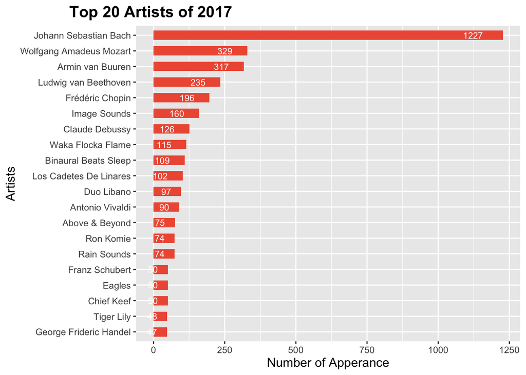

```r
top_artists <- df_cleaned %>%
            group_by(artist_name)  %>%
            summarise(n_apperance = n()) %>%
            filter(n_apperance > 1) %>%
            arrange(desc(n_apperance))
top_artists$artist_name <- factor(top_artists$artist_name,
                              levels = top_artists$artist_name[order(top_artists$n_apperance)])
top_artists <- top_artists[1:20 , ]

ggplot(top_artists, aes(x = artist_name, y = n_apperance)) +
  geom_bar(stat = "identity",  fill = "tomato2", width = 0.6 ) +
  labs(title = "Top 20 Artists of 2017", x = "Artists",
       y = "Number of Apperance") +
  theme(plot.title = element_text(size=15,hjust=-.3,face = "bold"),
        axis.title = element_text(size=12)) +
  geom_text(aes(label=n_apperance), hjust = 2, size = 3, color = 'white') +
  coord_flip()
```

### Density Distribution plot of Popularity

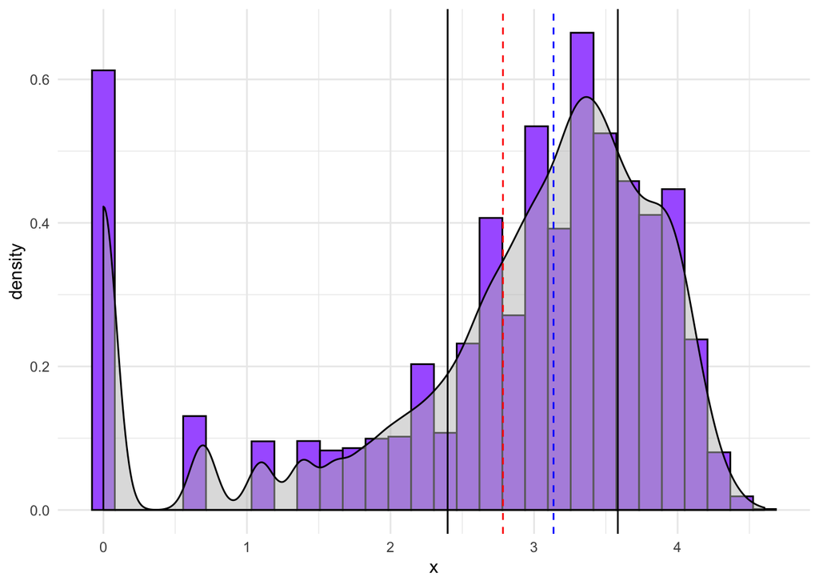

```r
popular_df <- data.frame(x = log(df_cleaned$popularity + 1))
Log_pol <- popular_df %>%
  ggplot(aes(x=x, fill = '#AA66FF'))+
  geom_histogram(aes(y=..density..), color = 'black', fill='#AA66FF')+
  geom_density(aes(y=..density..),color = 'black',fill = 'grey',  alpha = 0.5,
               kernel='gaussian')+
  geom_vline(aes(xintercept = mean(x)),color = 'red', linetype = 'dashed')+
  geom_vline(aes(xintercept = median(x)),color = 'blue', linetype = 'dashed')+
  geom_vline(aes(xintercept = quantile(x, probs = 0.25)),color = 'black')+
  geom_vline(aes(xintercept = quantile(x, probs = 0.75)),color = 'black')+
  theme_minimal()
Log_pol
```

### Top 5 Songs and their Variables Value

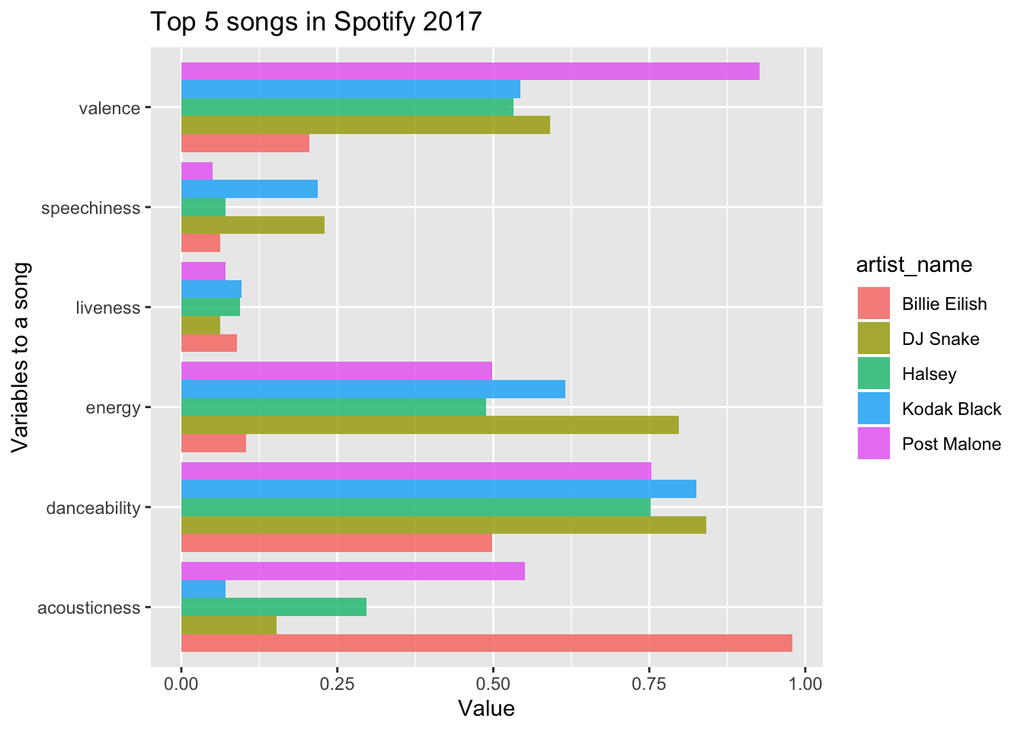

```r
#Data preparation for plot
topSongs <- df_cleaned %>%
  arrange(desc(popularity)) %>%
  slice(1:5) %>%
  dplyr::select(artist_name, acousticness,danceability, energy, liveness,
         speechiness, valence) %>%
  gather(key = "variables", value , -artist_name)

#Plot
ggplot(data=topSongs, aes(x=variables, y=value))+
  geom_bar(aes(y=value, fill=artist_name),stat="identity", alpha=0.8 , position="dodge")+
  ylab("Value")+
  xlab("Variables to a song")+
  coord_flip()+
  ggtitle("Top 5 songs in Spotify 2017 ")
```

### Top Artists by the Total Playing Time

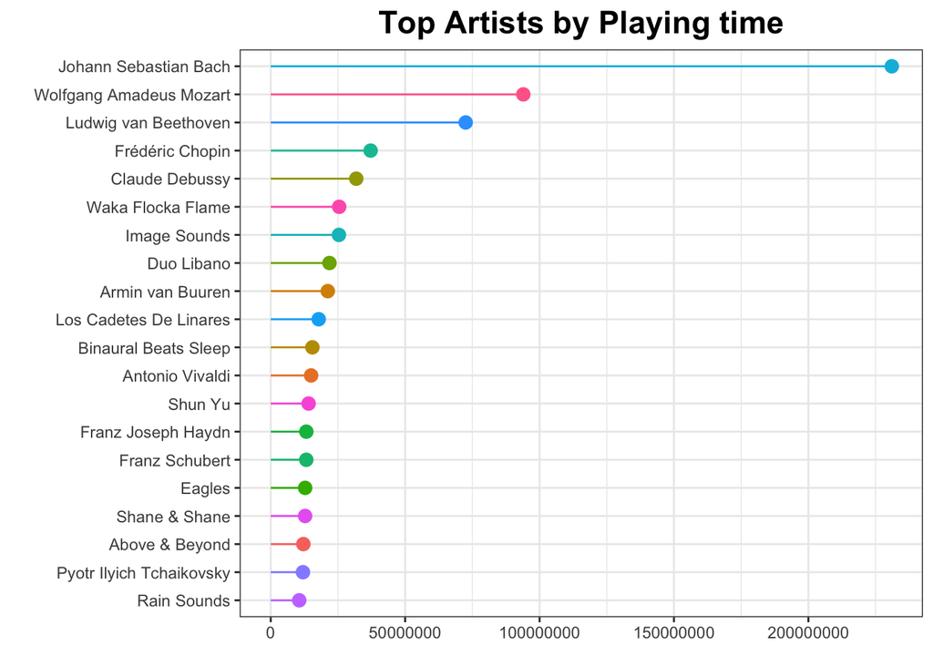

```r
top_by_playtime <-  df_cleaned %>%
  group_by(artist_name)  %>%
  summarise(time = sum(duration_ms)) %>%
  arrange(desc(time)) %>%
  top_n(20)

ggplot(top_by_playtime, aes(x=reorder(artist_name, time), y=time, color=artist_name)) +
  geom_point(size=3) +
  geom_segment(aes(x=artist_name,xend=artist_name, y=0, yend=time)) +
  labs(title = "Top Artists by Playing time", x='',y='') +
  theme_bw() +
  theme(legend.position = 'none', plot.title = element_text(size=17,hjust = 0.5, face = "bold"), axis.title.y = element_text(face = "bold"), axis.title.x = element_text(angle = 120)) +
  coord_flip()
```